# Predicting Machine Failures - A look at Imbalanced Classification

# Mining into Binary Variable Relationships

We have 5 binary features in addition to our target variable. Because there was no data dictionary included with this data, there's no way to note exaclty what these binary indicators represent, however, we can estimate their importance to our target variable with the use of confusion matrices.

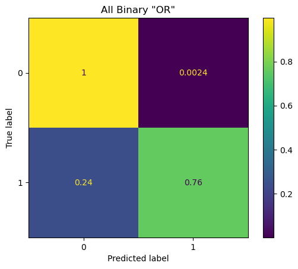

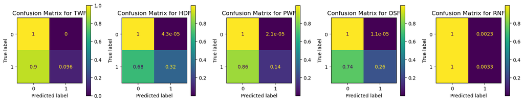

```python
# Creating a Confusion Matrix for all Binary Columns with "OR" Operator
ConfusionMatrixDisplay(confusion_matrix(y_train, pd.DataFrame(np.where((X_train['TWF']==1) | (X_train['HDF']==1) | (X_train['PWF']==1) | (X_train['OSF']==1) | (X_train['RNF']==1),
         1,
         0)), normalize = 'true')).plot()
plt.title('All Binary "OR"')
plt.show()

# Creating a vector of our Binary Columns
bina_cols = ['TWF', 'HDF', 'PWF', 'OSF', 'RNF']

fig, axes = plt.subplots(nrows=1, ncols=len(bina_cols), figsize=(15, 3))

for i, col in enumerate(bina_cols):
    ax = axes[i]
    ConfusionMatrixDisplay(confusion_matrix(y_train, X_train[col], normalize='true'), display_labels=[0, 1]).plot(ax=ax)
    ax.set_title(f'Confusion Matrix for {col}')

plt.tight_layout()
plt.show()
```

## Notes on Binary Variables:

We observed that a new binary feature, indicating whether any of the original binary indicators are positive, could be a valuable predictor for our models.

# Creating Data Preprocessing Pipelines

```python
# Defining a function to create the Binary column
def bina_col(X_dt):
    X_dt['binary_agg'] = np.where(
        (X_dt['TWF'] == 1) |
        (X_dt['HDF'] == 1) |
        (X_dt['PWF'] == 1) |
        (X_dt['OSF'] == 1) |
        (X_dt['RNF'] == 1),
        1, 0
    )
    return X_dt
# Transforming this function to be usable in a pipeline
bina_col_tr = FunctionTransformer(bina_col)


# Defining a function to remove unnecessary columns (including a bypass for binary indicators)
def col_remover(X_dt, bypass=False):
    if not bypass:
        return X_dt.drop(['id', 'Product ID', 'TWF', 'HDF', 'PWF', 'OSF', 'RNF'], axis=1)
    else:
        return X_dt.drop(['id', 'Product ID'], axis=1)

# Transforming this function to be usable in a pipeline
col_rem_tr = FunctionTransformer(col_remover, kw_args={'bypass': False})


# Defining a function to create the temperature ratio
def temp_ratio(X_dt):
    X_dt['Temp_Ratio'] = X_dt['Air temperature [K]']/X_dt['Process temperature [K]']
    return X_dt

# Transforming this function to be usable in a pipeline
temp_ratio_tr = FunctionTransformer(temp_ratio)


# Creating our categorical and numeric preprocessing pipelines
cat_prepr = make_pipeline(OneHotEncoder())
num_prepr = make_pipeline(StandardScaler())

preprocessing_pipeline = ColumnTransformer(
    transformers=[
        ('cat_tr', cat_prepr, col_remover(X_train).select_dtypes('object').columns),
        ('num_tr', num_prepr, col_remover(X_train).select_dtypes(exclude = 'object').columns)
    ],
    remainder = 'passthrough'
)

mast_pipeline = make_pipeline(bina_col_tr,
                         temp_ratio_tr,
                         col_rem_tr,
                         preprocessing_pipeline)




prepro_dat = mast_pipeline.fit_transform(X_train)
test_prepro = mast_pipeline.fit_transform(X_test)
```

```python
pd.DataFrame(prepro_dat).sample(10)
```

|  | 0 | 1 | 2 | 3 | 4 | 5 | 6 | 7 | 8 | 9 |
| --- | --- | --- | --- | --- | --- | --- | --- | --- | --- | --- |
| 32054 | 0.0 | 1.0 | 0.0 | -1.323080 | -1.184903 | 0.380656 | -0.699143 | 0.965051 | 0.0 | 0.964645 |
| 44938 | 0.0 | 1.0 | 0.0 | -2.181489 | -2.409741 | -0.643294 | 1.087025 | 0.167574 | 0.0 | 0.964775 |
| 56312 | 1.0 | 0.0 | 0.0 | -1.430381 | -1.112854 | -0.217850 | -0.076334 | 0.230122 | 0.0 | 0.963684 |
| 49132 | 0.0 | 1.0 | 0.0 | -1.430381 | -1.112854 | -0.477443 | 0.663985 | 1.043235 | 0.0 | 0.963684 |
| 77127 | 0.0 | 1.0 | 0.0 | -0.303719 | -1.040804 | 0.423922 | 0.111683 | 1.668706 | 0.0 | 0.970178 |
| 414 | 0.0 | 1.0 | 0.0 | -0.625622 | -0.320312 | 0.712358 | -0.041081 | 0.871230 | 0.0 | 0.965105 |
| 4199 | 0.0 | 1.0 | 0.0 | 1.091195 | -0.176213 | -0.535130 | 0.428963 | -1.364831 | 0.0 | 0.974814 |
| 79818 | 0.0 | 1.0 | 0.0 | -0.893875 | -1.545150 | 0.164329 | -0.828405 | -0.567355 | 0.0 | 0.968811 |
| 75758 | 0.0 | 1.0 | 0.0 | -0.947526 | -1.329002 | 0.863787 | -0.887161 | -0.614265 | 0.0 | 0.967543 |
| 10160 | 0.0 | 1.0 | 0.0 | -0.518321 | 0.111984 | -1.068738 | 0.816749 | -0.833180 | 0.0 | 0.963883 |

# Running our Classification Models

**We will run 6 total models:**

> - Decision Tree with Cost Sensitive Learning
> - Adaptive Boost Decision Trees with Cost Sensitive Learning
> - Hist Gradient Boosted Trees with Cost Sensitive Learning
> - Decision Tree with Synthetic Minority Oversampling Technique (SMOTE)
> - Adaptive Boost Decision Trees with Synthetic Minority Oversampling Technique (SMOTE)
> - Hist Gradient Boosted Trees with Synthetic Minority Oversampling Technique (SMOTE)

## Why use Decision Trees?

### *Basic Structure*

> Decision Trees are a type of model that splits data into branches to make decisions based on the features. At each node, the algorithm selects the feature that best separates the data into distinct classes.

### *Suitability for Imbalanced Learning*

> Decision Trees are intuitive and easy to understand. They can handle imbalanced data by assigning different weights to classes, which helps them focus more on the minority class. This makes them suitable for scenarios where certain outcomes (like machine failures) are rare but critical to identify.

## Why use AdaBoost Decision Trees?

### *Basic Structure*

> AdaBoost (Adaptive Boosting) is an ensemble learning technique that combines multiple weak classifiers, in our case Decision Trees, to create a strong classifier. It adjusts the weights of misclassified instances so that subsequent classifiers focus more on those cases.

### *Suitability for Imbalanced Learning*

> AdaBoost is effective for imbalanced datasets because it iteratively adjusts the weights of the instances, giving more attention to the minority class. By focusing on the harder-to-classify instances, AdaBoost can improve the model's ability to detect rare events like machine failures.

## Why use HGBoost?

### *Basic Structure*

> Hist Gradient Boosted Trees (HGBoost) is an ensemble technique that builds trees sequentially, each one correcting the errors of the previous ones. HGBoost uses histogram-based methods to bin continuous features, making the algorithm faster and more efficient than a typical Gradient Boosting Trees Algorithm.

### *Suitability for Imbalanced Learning*

> HGBoost is robust to imbalanced datasets due to its iterative approach in refining predictions. It can use customized loss functions and weight adjustments to handle the imbalance, making it a powerful tool for predicting rare events.

# The Importance of Using Comprehensive Evaluation Metrics in Imbalanced Classification

When dealing with machine learning models in the context of imbalanced datasets, relying on accuracy as an evaluation metric can be misleading and insufficient. Here’s why we cannot just use accuracy, sklearn's default evaluation metric, and why we need to use other metrics such as F1 score, ROC AUC, precision, and recall:

### *Understanding Accuracy*

Accuracy is defined as the ratio of correctly predicted instances to the total instances. While it provides a quick snapshot of overall model performance, it does not account for the distribution of class labels. In an imbalanced classification problem, where the majority class vastly outnumbers the minority class, a high accuracy can be achieved by simply predicting the majority class most of the time.

### *Limitations of Accuracy in Imbalanced Datasets*

Consider a scenario where 95% of the instances belong to the majority class (non-failure) and only 5% belong to the minority class (failure). A model that predicts all instances as the majority class will have an accuracy of 95%, but it completely fails to identify any of the minority class instances. This high accuracy gives a false sense of model effectiveness.

## Importance of Other Metrics

### *Precision and Recall:*

> **Precision measures** the proportion of true positive predictions (correctly predicted failures) out of all positive predictions (all predicted failures). High precision means that the model has a low false positive rate.

> **Recall (or Sensitivity)** measures the proportion of true positive predictions out of all actual positives (all actual failures). High recall means that the model captures most of the actual failures. In machine failure prediction, missing an actual failure (low recall) can be more costly than falsely predicting a failure (low precision). Therefore, recall might be prioritized in critical applications where preventing failures is crucial.

> The **F1 score** is the harmonic mean of precision and recall, providing a single metric that balances both concerns. It is particularly useful when we need to balance the trade-off between precision and recall. A balanced F1 score ensures that the model performs well in identifying failures without generating too many false alarms, making it suitable for operational decision-making.

> The **ROC AUC (Receiver Operating Characteristic - Area Under Curve)** metric evaluates the model's ability to distinguish between the positive and negative classes across various threshold settings. It provides an aggregate measure of performance across all classification thresholds. A high ROC AUC indicates that the model is good at distinguishing between machine failures and non-failures, which is crucial for reliable prediction in real-world applications.

# Cost Sensitive Learning

## Why use Cost-Sensitive Learning?

### *Basic Structure*

> Cost-Sensitive Learning involves modifying the learning process to take into account the cost associated with misclassifying different classes. This is usually done by assigning higher weights to the minority class during training.

### *Suitability for Imbalanced Learning*

> Cost-Sensitive Learning is particularly useful for imbalanced data as it directly addresses the imbalance by making the model more sensitive to the minority class. By increasing the penalty for misclassifying minority class instances, the model is incentivized to improve its performance on these critical cases.

### Decision Trees w Cost Sensitive Learning

```python
DT = DecisionTreeClassifier(criterion='log_loss')

# Configuring Parameter Grid for Hyperparameter Tuning
DT_prm = [{'min_samples_split':[2, 3, 4],
                  'class_weight':[{0:1, 1:9}, {0:1, 1:10}, {0:1, 1:11}, {0:1, 1:12}, {0:1, 1:13}],
                  'min_weight_fraction_leaf':[0.09, 0.1, 0.12],
                  'max_depth': [3, 5, 7, 10],
                  'min_samples_leaf': [1, 5, 10, 20]}]

# Initializing Stratified K-Fold Cross Validation
skf = StratifiedKFold(n_splits=10)

DT_cl = RandomizedSearchCV(DT,
                        DT_prm,
                        cv=skf,
                        scoring='f1')

# fitting the model
DT_cl.fit(prepro_dat, y_train)
print('done!')
```

```
done!
```

```python
ada_prm = [{'n_estimators': [250, 300, 350, 400]}]

ada = AdaBoostClassifier(
    DecisionTreeClassifier(max_depth = 1, criterion = 'log_loss'),
    algorithm="SAMME.R",
    learning_rate = 0.2
)

bdt_cl = RandomizedSearchCV(ada,
                   ada_prm,
                   cv=skf,
                   scoring='f1')


bdt_cl.fit(prepro_dat, y_train)
print('done!')
```

```
done!
```

### Hist Gradient Boost Trees w Cost Sensitive Learning

```python
HGB_prm = [{'learning_rate': [0.1, 0.01],
       'class_weight':[{0:1, 1:9}, {0:1, 1:10}, {0:1, 1:11}, {0:1, 1:12}, {0:1, 1:8}],
       'max_depth':[3, 5, 7, 9],
       'min_samples_leaf':[40, 50]}]

HGB = HistGradientBoostingClassifier()

HGB_cl = RandomizedSearchCV(HGB,
                   HGB_prm,
                   cv=skf,
                   scoring='f1')


HGB_cl.fit(prepro_dat, y_train)
print('done!')
```

```
done!
```

## Evaluating on Witheld Data (Test Data)

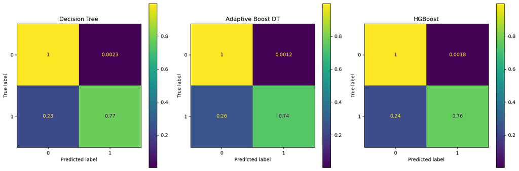

```python
fig, axes = plt.subplots(1, 3, figsize=(15, 5))

# Decision Tree
ConfusionMatrixDisplay(confusion_matrix(y_test, DT_cl.predict(test_prepro), normalize='true')).plot(ax=axes[0])
axes[0].set_title('Decision Tree')

# Adaptive Boost DT
ConfusionMatrixDisplay(confusion_matrix(y_test, bdt_cl.predict(test_prepro), normalize='true')).plot(ax=axes[1])
axes[1].set_title('Adaptive Boost DT')

# HGBoost
ConfusionMatrixDisplay(confusion_matrix(y_test, HGB_cl.predict(test_prepro), normalize='true')).plot(ax=axes[2])
axes[2].set_title('HGBoost')

# Adjust layout
plt.tight_layout()
plt.show()
```

```python
pd.DataFrame(
    {'f1': [f1_score(y_test, DT_cl.predict(test_prepro)),
            f1_score(y_test, bdt_cl.predict(test_prepro)),
            f1_score(y_test, HGB_cl.predict(test_prepro))
           ],
     'roc': [roc_auc_score(y_test, DT_cl.predict(test_prepro)),
            roc_auc_score(y_test, bdt_cl.predict(test_prepro)),
            roc_auc_score(y_test, HGB_cl.predict(test_prepro))
            ],
     'precision': [precision_score(y_test, DT_cl.predict(test_prepro)),
                  precision_score(y_test, bdt_cl.predict(test_prepro)),
                  precision_score(y_test, HGB_cl.predict(test_prepro))
                  ],
     'recall': [recall_score(y_test, DT_cl.predict(test_prepro)),
               recall_score(y_test, bdt_cl.predict(test_prepro)),
               recall_score(y_test, HGB_cl.predict(test_prepro))]
    }, index = ['Decision Tree', 'Ada Boost', 'HGBoost']
)
```

|  | f1 | roc | precision | recall |
| --- | --- | --- | --- | --- |
| Decision Tree | 0.807443 | 0.886268 | 0.842905 | 0.774845 |
| Ada Boost | 0.814751 | 0.868205 | 0.909962 | 0.737578 |
| HGBoost | 0.812242 | 0.880293 | 0.869027 | 0.762422 |

# Synthetic Minority Oversampling Technique

## Why use SMOTE?

### *Basic Structure*

> The Synthetic Minority Oversampling Technique (SMOTE) generates synthetic samples for the minority class by interpolating between existing minority instances. This balances the class distribution by increasing the number of minority class instances. This, however, should be used with caution for two reasons: First, it's feeding synthetic data into your model, which may introduce unnecessary noise. Second, it can be computationally expensive depending on the size of your dataset.

### *Suitability for Imbalanced Learning*

> SMOTE is effective for imbalanced datasets because it directly addresses the class imbalance by creating more examples of the minority class. This helps models learn the characteristics of the minority class better, leading to improved detection of rare events.

### Decision Tree w SMOTE

```python
smt = SMOTE(random_state=42)

DT_SMT_PIPL = Pipeline([('smt', smt),
                         ('dt', DT)])

SMDT_param_grid = [{'dt__min_samples_split':[2, 3, 4],
                  'dt__min_weight_fraction_leaf':[0.09, 0.1, 0.12],
                  'dt__max_depth': [3, 5, 7, 10],
                  'dt__min_samples_leaf': [1, 5, 10, 20]}]

SM_DT_srch = RandomizedSearchCV(DT_SMT_PIPL,
                        SMDT_param_grid,
                        cv=skf,
                        scoring='f1')

# fitting the model
SM_DT_srch.fit(prepro_dat, y_train)
print('done!')
```

```
done!
```

### Adaptive Boost Decision Trees w SMOTE

```python
ada_SMT_PIPL = Pipeline([('smt', smt),
                         ('ada', ada)])

SMT_ada_prm = [{'ada__n_estimators': [250, 300, 350, 400]}]

SMT_bdt = RandomizedSearchCV(ada_SMT_PIPL,
                   SMT_ada_prm,
                   cv=skf,
                   scoring='f1')


# fitting the model
SMT_bdt.fit(prepro_dat, y_train)
print('done!')
```

```
done!
```

### Hist Gradient Boosted Trees w SMOTE

```python
HGB_SMT_PIPL = Pipeline([('smt', smt),
                         ('HGB', HGB)])

SMT_HGB_prm = [{'HGB__learning_rate': [0.1, 0.01],
       'HGB__max_depth':[3, 5, 7, 9],
       'HGB__min_samples_leaf':[40, 50]}]


SMT_HGB_cl = RandomizedSearchCV(HGB_SMT_PIPL,
                   SMT_HGB_prm,
                   cv=skf,
                   scoring='f1')


SMT_HGB_cl.fit(prepro_dat, y_train)
print('done!')
```

```
done!
```

## Evaluating on Witheld Data (Test Data)

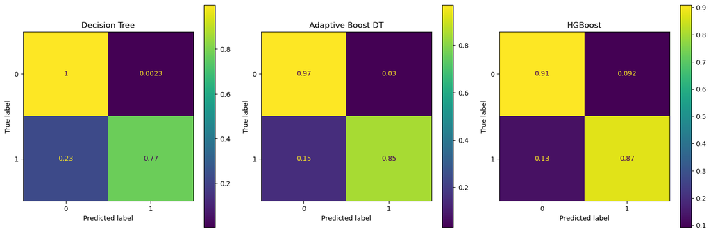

```python
fig, axes = plt.subplots(1, 3, figsize=(15, 5))

ConfusionMatrixDisplay(confusion_matrix(y_test, SM_DT_srch.predict(test_prepro),normalize = 'true')).plot(ax=axes[0])
axes[0].set_title('Decision Tree')

ConfusionMatrixDisplay(confusion_matrix(y_test, SMT_bdt.predict(test_prepro),normalize = 'true')).plot(ax=axes[1])
axes[1].set_title('Adaptive Boost DT')

ConfusionMatrixDisplay(confusion_matrix(y_test, SMT_HGB_cl.predict(test_prepro),normalize = 'true')).plot(ax=axes[2])
axes[2].set_title('HGBoost')

plt.tight_layout()
plt.show()
```

```python
pd.DataFrame(
    {'f1': [f1_score(y_test, SM_DT_srch.predict(test_prepro)),
            f1_score(y_test, SMT_bdt.predict(test_prepro)),
            f1_score(y_test, SMT_HGB_cl.predict(test_prepro))
           ],
     'roc': [roc_auc_score(y_test, SM_DT_srch.predict(test_prepro)),
            roc_auc_score(y_test, SMT_bdt.predict(test_prepro)),
            roc_auc_score(y_test, SMT_HGB_cl.predict(test_prepro))
            ],
     'precision': [precision_score(y_test, SM_DT_srch.predict(test_prepro)),
                  precision_score(y_test, SMT_bdt.predict(test_prepro)),
                  precision_score(y_test, SMT_HGB_cl.predict(test_prepro))
                  ],
     'recall': [recall_score(y_test, SM_DT_srch.predict(test_prepro)),
               recall_score(y_test, SMT_bdt.predict(test_prepro)),
               recall_score(y_test, SMT_HGB_cl.predict(test_prepro))]
    }, index = ['Decision Tree', 'Ada Boost', 'HGBoost']
)
```

|  | f1 | roc | precision | recall |
| --- | --- | --- | --- | --- |
| Decision Tree | 0.807443 | 0.886268 | 0.842905 | 0.774845 |
| Ada Boost | 0.457215 | 0.908305 | 0.313218 | 0.846273 |
| HGBoost | 0.229669 | 0.890562 | 0.132235 | 0.872671 |

# Comparing All Models (Cost-Sensitive & Oversampled)

```python
pd.DataFrame(
    {'f1': [f1_score(y_test, DT_cl.predict(test_prepro)),
            f1_score(y_test, SM_DT_srch.predict(test_prepro)),
            f1_score(y_test, bdt_cl.predict(test_prepro)),
            f1_score(y_test, SMT_bdt.predict(test_prepro)),
            f1_score(y_test, HGB_cl.predict(test_prepro)),
            f1_score(y_test, SMT_HGB_cl.predict(test_prepro))
           ],
     'roc': [roc_auc_score(y_test, DT_cl.predict(test_prepro)),
             roc_auc_score(y_test, SM_DT_srch.predict(test_prepro)),
             roc_auc_score(y_test, bdt_cl.predict(test_prepro)),
            roc_auc_score(y_test, SMT_bdt.predict(test_prepro)),
             roc_auc_score(y_test, HGB_cl.predict(test_prepro)),
            roc_auc_score(y_test, SMT_HGB_cl.predict(test_prepro))
            ],
     'precision': [precision_score(y_test, DT_cl.predict(test_prepro)),
                   precision_score(y_test, SM_DT_srch.predict(test_prepro)),
                   precision_score(y_test, bdt_cl.predict(test_prepro)),
                   precision_score(y_test, SMT_bdt.predict(test_prepro)),
                   precision_score(y_test, HGB_cl.predict(test_prepro)),
                  precision_score(y_test, SMT_HGB_cl.predict(test_prepro))
                  ],
     'recall': [recall_score(y_test, DT_cl.predict(test_prepro)),
                recall_score(y_test, SM_DT_srch.predict(test_prepro)),
                recall_score(y_test, bdt_cl.predict(test_prepro)),
                recall_score(y_test, SMT_bdt.predict(test_prepro)),
                recall_score(y_test, HGB_cl.predict(test_prepro)),
                recall_score(y_test, SMT_HGB_cl.predict(test_prepro))]
    }, index = ['Decision Tree', 'SMOTE Decision Tree', 'AdaBoost', 'SMOTE AdaBoost','HGBoost', 'SMOTE HGBoost']
)
```

|  | f1 | roc | precision | recall |
| --- | --- | --- | --- | --- |
| Decision Tree | 0.807443 | 0.886268 | 0.842905 | 0.774845 |
| SMOTE Decision Tree | 0.807443 | 0.886268 | 0.842905 | 0.774845 |
| AdaBoost | 0.814751 | 0.868205 | 0.909962 | 0.737578 |
| SMOTE AdaBoost | 0.457215 | 0.908305 | 0.313218 | 0.846273 |
| HGBoost | 0.812242 | 0.880293 | 0.869027 | 0.762422 |
| SMOTE HGBoost | 0.229669 | 0.890562 | 0.132235 | 0.872671 |

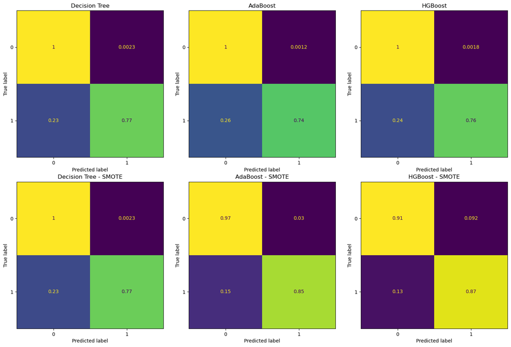

```python
# Models without SMOTE
models_no_smote = [DT_cl, bdt_cl, HGB_cl]
titles_no_smote = ['Decision Tree', 'AdaBoost', 'HGBoost']

# Models with SMOTE
models_smote = [SM_DT_srch, SMT_bdt, SMT_HGB_cl]
titles_smote = ['Decision Tree - SMOTE', 'AdaBoost - SMOTE', 'HGBoost - SMOTE']

# Set up a 2x3 grid of plots
fig, axes = plt.subplots(2, 3, figsize=(15, 10))

# Plot confusion matrices for models without SMOTE
for i, (model, title) in enumerate(zip(models_no_smote, titles_no_smote)):
    cm = confusion_matrix(y_test, model.predict(test_prepro), normalize='true')
    disp = ConfusionMatrixDisplay(confusion_matrix=cm)
    disp.plot(ax=axes[0, i], colorbar=False)
    axes[0, i].set_title(title)

# Plot confusion matrices for models with SMOTE
for i, (model, title) in enumerate(zip(models_smote, titles_smote)):
    cm = confusion_matrix(y_test, model.predict(test_prepro), normalize='true')
    disp = ConfusionMatrixDisplay(confusion_matrix=cm)
    disp.plot(ax=axes[1, i], colorbar=False)
    axes[1, i].set_title(title)

# Adjust layout to avoid overlap
plt.tight_layout()
plt.show()
```

## Performance Evaluation

From the confusion matrices, we can see that each model had varying success in correctly predicting the machine failures (minority class):

> - **Decision Tree without SMOTE:** Achieved an F1 score of 0.8074, with a precision of 0.8429 and recall of 0.7748. This model showed a good balance between precision and recall.
> - **Decision Tree with SMOTE:** Showed identical performance metrics to the Decision Tree without SMOTE, indicating that SMOTE did not improve this particular model.
> - **AdaBoost without SMOTE:** Achieved the highest F1 score among the models at 0.8148, with a high precision of 0.9099 but lower recall at 0.7376. This suggests AdaBoost is better at avoiding false positives but may miss some true positives.
> - **AdaBoost with SMOTE:** Demonstrated a significant drop in F1 score to 0.4572, with a much lower precision (0.3132) but high recall (0.8463). This indicates that while AdaBoost with SMOTE is good at identifying true positives, it also has a high rate of false positives.
> - **HGBoost without SMOTE:** Had a strong performance with an F1 score of 0.8122, precision of 0.8690, and recall of 0.7624. This model also maintained a good balance between precision and recall.
> - **HGBoost with SMOTE:** Had the lowest F1 score of 0.2297, indicating that applying SMOTE did not benefit this model and resulted in a very high rate of false positives (precision of 0.1322) despite having high recall (0.8727).

## Business Use-Case Considerations

Different business cases might prioritize different evaluation metrics based on the specific needs and consequences of misclassification:

> **When Precision is More Important:** In cases where false positives are costly or highly disruptive (e.g., fraud detection, where flagging a legitimate transaction as fraud can cause inconvenience and loss of trust), models like AdaBoost without SMOTE (high precision of 0.9099) would be preferred. High precision ensures that when the model predicts a failure, it is likely to be correct.

> **When Recall is More Important:** In scenarios where missing a positive instance is highly undesirable (e.g., medical diagnoses, where failing to identify a disease could have severe consequences), models with higher recall should be chosen. For instance, AdaBoost with SMOTE has a high recall of 0.8463, meaning it is effective at capturing most of the actual machine failures.

# Decision Threshold Adjustments

> To further tailor to various business use-cases, we can manually tune the decision thresholds. Decision thresholds in classification problems determine how predicted probabilities are translated into class labels. The default threshold is usually 0.5, where predictions above 0.5 are classified as positive (class 1) and below as negative (class 0). Setting the decision threshold manually and optimizing for different metrics like precision, recall or F1-score can be looked at as a final 'tuning' of our predictions. Below is a look at this process using a custom function that finds the optinal threshold for optimizing different metric scores.

```python
def optimal_threshold(model, X_test, y_test, metric):
    """
    Finds the optimal threshold for a given model to maximize the F1 score.

    Parameters:
    model: Trained classifier
    X_test: Features of the test set
    y_test: True labels of the test set

    Returns:
    best_threshold: Threshold that maximizes the F1 score
    metrics: Dictionary containing the F1 score, accuracy, precision, recall, and ROC AUC score
    """
    y_pred_proba = model.predict_proba(X_test)[:, 1]

    # Initialize variables to store the best F1 score and corresponding threshold
    best_threshold = 0.0
    best_score = 0.0

    # Generate possible thresholds
    thresholds = np.arange(0.0, 1.0, 0.01)

    if metric == 'f1':
        # Iterate through thresholds to find the best one
        for threshold in thresholds:
            y_pred = (y_pred_proba >= threshold).astype(int)
            current_score = f1_score(y_test, y_pred)
            if current_score > best_score:
                best_score = current_score
                best_threshold = threshold

    if metric == 'precision':
        # Iterate through thresholds to find the best one
        for threshold in thresholds:
            y_pred = (y_pred_proba >= threshold).astype(int)
            current_score = precision_score(y_test, y_pred)
            if current_score > best_score:
                best_score = current_score
                best_threshold = threshold

    if metric == 'recall':
        # Iterate through thresholds to find the best one
        for threshold in thresholds:
            y_pred = (y_pred_proba >= threshold).astype(int)
            current_score = recall_score(y_test, y_pred)
            if current_score > best_score:
                best_score = current_score
                best_threshold = threshold


    # Predict with the optimal threshold
    y_pred_optimal = (y_pred_proba >= best_threshold).astype(int)

    # Calculate other metrics with the optimal threshold
    metrics = {
        'Threshold': best_threshold,
        'F1 Score': f1_score(y_test, y_pred_optimal),
        'Precision': precision_score(y_test, y_pred_optimal),
        'Recall': recall_score(y_test, y_pred_optimal)
    }

    return metrics


all_models = models_no_smote + models_smote
all_titles = titles_no_smote + titles_smote
```

```python
# filter out warnings
warnings.filterwarnings('ignore')


# Create a DataFrame to store the results
results_precision = pd.DataFrame(columns=['Model', 'Threshold', 'F1 Score', 'Precision', 'Recall'])

# Iterate through all models and find the optimal thresholds to maximize precision
for model, title in zip(all_models, all_titles):
    metrics = optimal_threshold(model, test_prepro, y_test, 'precision')
    metrics['Model'] = title
    results_precision = results_precision.append(metrics, ignore_index=True)

# Set the Model column as the index
results_precision.set_index('Model', inplace=True)

results_precision
```

| Model | Threshold | F1 Score | Precision | Recall |
| --- | --- | --- | --- | --- |
| Decision Tree | 0.16 | 0.807443 | 0.842905 | 0.774845 |
| AdaBoost | 0.53 | 0.060241 | 1.000000 | 0.031056 |
| HGBoost | 0.68 | 0.659898 | 0.953079 | 0.504658 |
| Decision Tree - SMOTE | 0.40 | 0.807443 | 0.842905 | 0.774845 |
| AdaBoost - SMOTE | 0.55 | 0.042553 | 1.000000 | 0.021739 |
| HGBoost - SMOTE | 0.99 | 0.814750 | 0.937374 | 0.720497 |

```python
# Create a DataFrame to store the results
results_f1 = pd.DataFrame(columns=['Model', 'Threshold', 'F1 Score', 'Precision', 'Recall'])

# Iterate through all models and find the optimal thresholds to maximize the f1 score
for model, title in zip(all_models, all_titles):
    metrics = optimal_threshold(model, test_prepro, y_test, 'f1')
    metrics['Model'] = title
    results_f1 = results_f1.append(metrics, ignore_index=True)

# Set the Model column as the index
results_f1.set_index('Model', inplace=True)

results_f1
```

| Model | Threshold | F1 Score | Precision | Recall |
| --- | --- | --- | --- | --- |
| Decision Tree | 0.16 | 0.807443 | 0.842905 | 0.774845 |
| AdaBoost | 0.50 | 0.814751 | 0.909962 | 0.737578 |
| HGBoost | 0.53 | 0.824129 | 0.909944 | 0.753106 |
| Decision Tree - SMOTE | 0.40 | 0.807443 | 0.842905 | 0.774845 |
| AdaBoost - SMOTE | 0.52 | 0.812925 | 0.898496 | 0.742236 |
| HGBoost - SMOTE | 0.98 | 0.823932 | 0.916350 | 0.748447 |

# Conclusion

In this project aimed at predicting machine failures, we evaluated six different models using three different algorithms (Decision Tree, AdaBoost, and Hist Gradient Boosting) with and without the application of the Synthetic Minority Oversampling Technique (SMOTE). Additionally, we tuned decision thresholds with different business use-cases in mind. The goal was to handle the inherent class imbalance in our dataset and determine which model configurations provided the best performance.